# Final Project

Ang Chen

# 1. BASIC SETUP

Given the description, I decided to make a logstic regression model to solbe the problem. In the basic setup section, we would choose influencing features and the indicate the labels from the dataset provided.

## Variable selection

Using the cup98dic.txt provided, we chose 10 features: RFA_2R Recency code for RFA_2  
RFA_2F Frequency code for RFA_2  
RFA_2A Donation Amount code for RFA_2 HOMEOWNR Home Owner Flag H = Home owner U = Unknown CLUSTER CLUSTER Code indicating which cluster group the donor falls into.  
Each cluster is unique in terms of socio-economic status, urbanicty, ethnicity and a variety of other demographic characteristics. A nominal or symbolic field. INCOME HOUSEHOLD INCOME GENDER Gender M = Male F = Female U = Unknown J = Joint Account, unknown gender STATE State abbreviation (a nominal/symbolic field) DATASRCE Source of Overlay Data Indicates which third-party data source the donor matched against 1 = MetroMail 2 = Polk 3 = Both VETERANS VETERANS (Y/N)

## Target Variable Selection

We selected the label TARGET_B indicating whether the response is positive or negtive. TARGET_B Target Variable: Binary Indicator for Response to 97NK Mailing

# Model Building

We are going to build a logistic regression model in this section to classify whether the receive will be a donor. The steps are as below.

## Libraries Installation

Running this code should pretty much cover all the technique we need for the model.

```r
library(data.table)
```

```r
library(ggplot2)
library(mice)
library(VIM)
library(mlbench)
library(caret)
library(gmodels)
library(vcd)
library(vcdExtra)
library(ca)
library(MASS)
library(formatR)
library(tidyr)
library(tibble)
library(dplyr)
library(stringr)
library(haven)
```

## Loading Data

First we would want to load the data

```r
#Fist we define a dataset containing all the data we need
rawdataset <- read.csv("C:/Users/Administrator/Desktop/BUS 5420/final project/cup98LRN.txt")
rawdataset <- rawdataset[c("RFA_2R", "RFA_2F", "RFA_2A",  "HOMEOWNR", "CLUSTER", "GENDER", "INCOME", "STATE", "DATASRCE", "VETERANS", "TARGET_B", "TARGET_D")]
head(rawdataset)
```

|  | RFA_2R | RFA_2F | RFA_2A | HOMEOWNR | CLUSTER | GENDER | INCOME | STATE | DATASRCE | VETERANS | TARGET_B | TARGET_D |
| --- | --- | --- | --- | --- | --- | --- | --- | --- | --- | --- | --- | --- |
| 1 | L | 4 | E |  | 36 | F | NA | IL | NA |  | 0 | 0 |
| 2 | L | 2 | G | H | 14 | M | 6 | CA | 3 |  | 0 | 0 |
| 3 | L | 4 | E | U | 43 | M | 3 | NC | 3 |  | 0 | 0 |
| 4 | L | 4 | E | U | 44 | F | 1 | CA | 3 |  | 0 | 0 |
| 5 | L | 2 | F | H | 16 | F | 3 | FL | 3 |  | 0 | 0 |
| 6 | L | 1 | F |  | 40 |  | NA | AL | NA |  | 0 | 0 |

## Data Cleaning

From loading the data, some white-spaces are found. We need to transform the white-spaces into NA while looking for other problems.

```r
str(rawdataset)  #see if there is any problems with the datatype
```

```
## 'data.frame':    95775 obs. of  12 variables:
##  $ RFA_2R  : Factor w/ 2 levels "","L": 2 2 2 2 2 2 2 2 2 2 ...
##  $ RFA_2F  : int  4 2 4 4 2 1 1 3 1 1 ...
##  $ RFA_2A  : Factor w/ 5 levels "","D","E","F",..: 3 5 3 3 4 4 3 3 4 4 ...
##  $ HOMEOWNR: Factor w/ 3 levels " ","H","U": 1 2 3 3 2 1 2 3 3 1 ...
##  $ CLUSTER : int  36 14 43 44 16 40 40 39 45 35 ...
##  $ GENDER  : Factor w/ 6 levels " ","C","F","J",..: 3 5 5 3 3 1 3 3 5 5 ...
##  $ INCOME  : int  NA 6 3 1 3 NA 4 2 3 NA ...
##  $ STATE   : Factor w/ 57 levels "AA","AE","AK",..: 20 9 33 9 14 4 21 24 18 48 ...
##  $ DATASRCE: int  NA 3 3 3 3 NA 3 1 3 NA ...
##  $ VETERANS: Factor w/ 2 levels " ","Y": 1 1 1 1 1 1 1 1 1 1 ...
##  $ TARGET_B: int  0 0 0 0 0 0 0 0 0 0 ...
##  $ TARGET_D: num  0 0 0 0 0 0 0 0 0 0 ...
```

```r
head(rawdataset)  #see the first few rows of data
```

|  | RFA_2R | RFA_2F | RFA_2A | HOMEOWNR | CLUSTER | GENDER | INCOME | STATE | DATASRCE | VETERANS | TARGET_B | TARGET_D |
| --- | --- | --- | --- | --- | --- | --- | --- | --- | --- | --- | --- | --- |
| 1 | L | 4 | E |  | 36 | F | NA | IL | NA |  | 0 | 0 |
| 2 | L | 2 | G | H | 14 | M | 6 | CA | 3 |  | 0 | 0 |
| 3 | L | 4 | E | U | 43 | M | 3 | NC | 3 |  | 0 | 0 |
| 4 | L | 4 | E | U | 44 | F | 1 | CA | 3 |  | 0 | 0 |
| 5 | L | 2 | F | H | 16 | F | 3 | FL | 3 |  | 0 | 0 |
| 6 | L | 1 | F |  | 40 |  | NA | AL | NA |  | 0 | 0 |

```r
summary(rawdataset)  # overview the dataset
```

```
##  RFA_2R        RFA_2F      RFA_2A    HOMEOWNR     CLUSTER      GENDER
##   :  574   Min.   :1.000    :  574    :20332   Min.   : 1.00    : 3129
##  L:95201   1st Qu.:1.000   D: 7952   H:53832   1st Qu.:13.00   C:    1
##            Median :1.000   E:21511   U:21611   Median :27.00   F:51563
##            Mean   :1.903   F:46891             Mean   :27.02   J:  244
##            3rd Qu.:3.000   G:18847             3rd Qu.:40.00   M:39096
##            Max.   :4.000                       Max.   :53.00   U: 1742
##            NA's   :574                         NA's   :3818
##      INCOME          STATE          DATASRCE     VETERANS
##  Min.   :1.000   CA     :18649   Min.   :1.000    :85289
##  1st Qu.:3.000   FL     : 9170   1st Qu.:2.000   Y:10486
##  Median :4.000   IL     : 8271   Median :3.000
##  Mean   :4.167   TX     : 5765   Mean   :2.504
##  3rd Qu.:5.000   MI     : 4416   3rd Qu.:3.000
##  Max.   :7.000   WA     : 4135   Max.   :3.000
##  NA's   :19711   (Other):45369   NA's   :19707
##     TARGET_B         TARGET_D
##  Min.   :0.0000   Min.   :  0.0000
##  1st Qu.:0.0000   1st Qu.:  0.0000
##  Median :0.0000   Median :  0.0000
##  Mean   :0.0527   Mean   :  0.8523
##  3rd Qu.:0.0000   3rd Qu.:  0.0000
##  Max.   :1.0000   Max.   :200.0000
##  NA's   :574      NA's   :574
```

According to the results, the datatypes all seem to be reasonable. However, it is found that there indeed are some nuls and white spaces, which we need to fix.

### Dealing with white spaces

We need to convert white spaces into NA type. It is as following.

```r
#notice the blanks
rawdataset$HOMEOWNR[1:10]
```

```
##  [1]   H U U H   H U U
## Levels:   H U
```

```r
#Found some empty. Use mutate to change blanks into NAs
t_df <- rawdataset %>% mutate_all(str_trim)  # first, str and trim data
rna_df <- t_df %>% mutate_all(zap_empty)  # fill in the blanks with NAs

rna_df$HOMEOWNR[1:10]
```

```
##  [1] NA  "H" "U" "U" "H" NA  "H" "U" "U" NA
```

```r
str(rna_df)
```

```
## 'data.frame':    95775 obs. of  12 variables:
##  $ RFA_2R  : chr  "L" "L" "L" "L" ...
##  $ RFA_2F  : chr  "4" "2" "4" "4" ...
##  $ RFA_2A  : chr  "E" "G" "E" "E" ...
##  $ HOMEOWNR: chr  NA "H" "U" "U" ...
##  $ CLUSTER : chr  "36" "14" "43" "44" ...
##  $ GENDER  : chr  "F" "M" "M" "F" ...
##  $ INCOME  : chr  NA "6" "3" "1" ...
##  $ STATE   : chr  "IL" "CA" "NC" "CA" ...
##  $ DATASRCE: chr  NA "3" "3" "3" ...
##  $ VETERANS: chr  NA NA NA NA ...
##  $ TARGET_B: chr  "0" "0" "0" "0" ...
##  $ TARGET_D: chr  "0" "0" "0" "0" ...
```

### Change Data type

Due to the white-space filling, the data types have been changed into character type. Thus, we need to modify the data types to correct forms. (All factor type in this case)

```r
# assiagn datatype "factor"
typed_df <- rna_df %>% mutate_if(is.character, as.factor)

summary(typed_df)
```

```
##   RFA_2R       RFA_2F       RFA_2A      HOMEOWNR        CLUSTER
##  L   :95201   1   :48427   D   : 7952   H   :53832   27     : 4705
##  NA's:  574   2   :19119   E   :21511   U   :21611   49     : 4496
##               3   :16117   F   :46891   NA's:20332   14     : 3799
##               4   :11538   G   :18847                12     : 3769
##               NA's:  574   NA's:  574                36     : 3598
##                                                      (Other):71590
##                                                      NA's   : 3818
##   GENDER          INCOME          STATE       DATASRCE     VETERANS
##  C   :    1   5      :17918   CA     :18649   1   : 7205   Y   :10486
##  F   :51563   4      :12652   FL     : 9170   2   :23333   NA's:85289
##  J   :  244   7      :11967   IL     : 8271   3   :45530
##  M   :39096   2      :11834   TX     : 5765   NA's:19707
##  U   : 1742   3      : 9208   MI     : 4416
##  NA's: 3129   (Other):12485   WA     : 4135
##               NA's   :19711   (Other):45369
##  TARGET_B        TARGET_D
##  0   :90186   0      :90186
##  1   : 5015   10     : 1206
##  NA's:  574   12     :  682
##               30     :  638
##               20     :  420
##               (Other): 2069
##               NA's   :  574
```

```r
str(typed_df)
```

```
## 'data.frame':    95775 obs. of  12 variables:
##  $ RFA_2R  : Factor w/ 1 level "L": 1 1 1 1 1 1 1 1 1 1 ...
##  $ RFA_2F  : Factor w/ 4 levels "1","2","3","4": 4 2 4 4 2 1 1 3 1 1 ...
##  $ RFA_2A  : Factor w/ 4 levels "D","E","F","G": 2 4 2 2 3 3 2 2 3 3 ...
##  $ HOMEOWNR: Factor w/ 2 levels "H","U": NA 1 2 2 1 NA 1 2 2 NA ...
##  $ CLUSTER : Factor w/ 53 levels "1","10","11",..: 30 6 38 39 8 35 35 33 40 29 ...
##  $ GENDER  : Factor w/ 5 levels "C","F","J","M",..: 2 4 4 2 2 NA 2 2 4 4 ...
##  $ INCOME  : Factor w/ 7 levels "1","2","3","4",..: NA 6 3 1 3 NA 4 2 3 NA ...
##  $ STATE   : Factor w/ 57 levels "AA","AE","AK",..: 20 9 33 9 14 4 21 24 18 48 ...
##  $ DATASRCE: Factor w/ 3 levels "1","2","3": NA 3 3 3 3 NA 3 1 3 NA ...
##  $ VETERANS: Factor w/ 1 level "Y": NA NA NA NA NA NA NA NA NA NA ...
##  $ TARGET_B: Factor w/ 2 levels "0","1": 1 1 1 1 1 1 1 1 1 1 ...
##  $ TARGET_D: Factor w/ 65 levels "0","1","10","10.7",..: 1 1 1 1 1 1 1 1 1 1 ...
```

### Dealing with missing data

From the summary of dataset, we found that there are a lot of NAs. Now we are going to visualize these NAs and use corresponding treatment.

```r
# Visualize the NAs
library(mice)
library(VIM)
md.pattern(typed_df)  # Display missing data patterns
```

```
##       STATE RFA_2R RFA_2F RFA_2A TARGET_B TARGET_D GENDER CLUSTER DATASRCE
##  8577     1      1      1      1        1        1      1       1        1
##    78     1      1      1      1        1        1      1       1        1
##   706     1      1      1      1        1        1      1       0        1
## 63031     1      1      1      1        1        1      1       1        1
##    16     1      1      1      1        1        1      1       0        1
##   392     1      1      1      1        1        1      1       1        1
##  2551     1      1      1      1        1        1      1       0        1
##     4     1      1      1      1        1        1      1       1        1
##   456     1      1      1      1        1        1      1       1        0
##   139     1      1      1      1        1        1      1       0        1
##    11     1      1      1      1        1        1      1       0        0
##    66     1      1      1      1        1        1      0       1        0
## 15787     1      1      1      1        1        1      1       1        0
##     3     1      1      1      1        1        1      0       0        0
```

[output cut: 27 more lines]

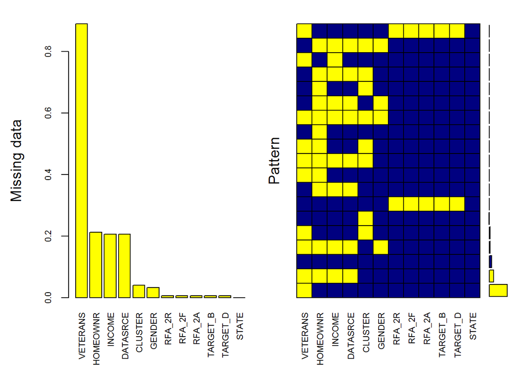

```
##
##  Variables sorted by number of missings:
##  Variable       Count
##  VETERANS 0.890514226
##  HOMEOWNR 0.212289220
##    INCOME 0.205805273
##  DATASRCE 0.205763508
##   CLUSTER 0.039864265
##    GENDER 0.032670321
##    RFA_2R 0.005993213
##    RFA_2F 0.005993213
##    RFA_2A 0.005993213
##  TARGET_B 0.005993213
##  TARGET_D 0.005993213
##     STATE 0.000000000
```

```r
mice_plot<-aggr(typed_df,col=c('navyblue','yellow'),combined=FALSE,numbers=TRUE,
                sortVars=TRUE,labels=names(typed_df),cex.axis=.7,
                gap=3,ylab=c("Missing data","Pattern"))
```

From the visualization, we can see that the “VETERANS” column has the most NAs. The NAs represent non-veterans, which means we exchange the NA with Ns.

```r
fixed_df <- typed_df
fixed_df$VETERANS <- as.character(fixed_df$VETERANS) # we need to transfer datatype to char
str(fixed_df)
```

```
## 'data.frame':    95775 obs. of  12 variables:
##  $ RFA_2R  : Factor w/ 1 level "L": 1 1 1 1 1 1 1 1 1 1 ...
##  $ RFA_2F  : Factor w/ 4 levels "1","2","3","4": 4 2 4 4 2 1 1 3 1 1 ...
##  $ RFA_2A  : Factor w/ 4 levels "D","E","F","G": 2 4 2 2 3 3 2 2 3 3 ...
##  $ HOMEOWNR: Factor w/ 2 levels "H","U": NA 1 2 2 1 NA 1 2 2 NA ...
##  $ CLUSTER : Factor w/ 53 levels "1","10","11",..: 30 6 38 39 8 35 35 33 40 29 ...
##  $ GENDER  : Factor w/ 5 levels "C","F","J","M",..: 2 4 4 2 2 NA 2 2 4 4 ...
##  $ INCOME  : Factor w/ 7 levels "1","2","3","4",..: NA 6 3 1 3 NA 4 2 3 NA ...
##  $ STATE   : Factor w/ 57 levels "AA","AE","AK",..: 20 9 33 9 14 4 21 24 18 48 ...
##  $ DATASRCE: Factor w/ 3 levels "1","2","3": NA 3 3 3 3 NA 3 1 3 NA ...
##  $ VETERANS: chr  NA NA NA NA ...
##  $ TARGET_B: Factor w/ 2 levels "0","1": 1 1 1 1 1 1 1 1 1 1 ...
##  $ TARGET_D: Factor w/ 65 levels "0","1","10","10.7",..: 1 1 1 1 1 1 1 1 1 1 ...
```

```r
fixed_df[is.na(fixed_df$VETERANS), "VETERANS"] <- "N" # set all NA as "N"
fixed_df$VETERANS <- as.factor(fixed_df$VETERANS) # Transfer back to factor type

summary(fixed_df) # check
```

```
##   RFA_2R       RFA_2F       RFA_2A      HOMEOWNR        CLUSTER
##  L   :95201   1   :48427   D   : 7952   H   :53832   27     : 4705
##  NA's:  574   2   :19119   E   :21511   U   :21611   49     : 4496
##               3   :16117   F   :46891   NA's:20332   14     : 3799
##               4   :11538   G   :18847                12     : 3769
##               NA's:  574   NA's:  574                36     : 3598
##                                                      (Other):71590
##                                                      NA's   : 3818
##   GENDER          INCOME          STATE       DATASRCE     VETERANS
##  C   :    1   5      :17918   CA     :18649   1   : 7205   N:85289
##  F   :51563   4      :12652   FL     : 9170   2   :23333   Y:10486
##  J   :  244   7      :11967   IL     : 8271   3   :45530
##  M   :39096   2      :11834   TX     : 5765   NA's:19707
##  U   : 1742   3      : 9208   MI     : 4416
##  NA's: 3129   (Other):12485   WA     : 4135
##               NA's   :19711   (Other):45369
##  TARGET_B        TARGET_D
##  0   :90186   0      :90186
##  1   : 5015   10     : 1206
##  NA's:  574   12     :  682
##               30     :  638
##               20     :  420
##               (Other): 2069
##               NA's   :  574
```

Although we fixed the missing value of VETERAN, there are still some NAs. However, the numbers of the remaining are still a lot. Thus, we just need to remove all rows with NA and see how much is remianed.

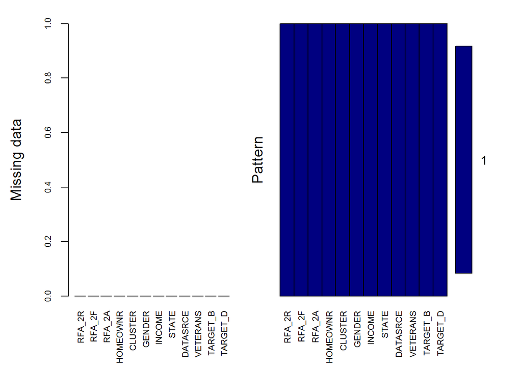

```
##
##  Variables sorted by number of missings:
##  Variable Count
##    RFA_2R     0
##    RFA_2F     0
##    RFA_2A     0
##  HOMEOWNR     0
##   CLUSTER     0
##    GENDER     0
##    INCOME     0
##     STATE     0
##  DATASRCE     0
##  VETERANS     0
##  TARGET_B     0
##  TARGET_D     0
```

```r
#Remove rows with NAs.
clean_df<-na.omit(fixed_df)

mice_plot<-aggr(clean_df,col=c('navyblue','yellow'),combined=FALSE,numbers=TRUE,
                sortVars=TRUE,labels=names(typed_df),cex.axis=.7,
                gap=3,ylab=c("Missing data","Pattern")) # see how much is remaining
```

## Create training and validation data set

We want to know the quality of our model. Thus, we would isolate a part of the data from the dataset and use it as a validation data set. In this project, we would use 80% of the data as learning dataset and 20% as validation dataset.

```r
library(caret)
'%ni%' <- Negate('%in%')  # define 'not in' func
options(scipen=999)  # prevents printing scientific notations.

#Create an index seperating the original dataset at 80%
validation_index <- createDataPartition(clean_df$TARGET_B, p=0.8, list=FALSE)
#Create a training dataset using 80% of the original dataset
trainData <- clean_df[validation_index,]
#Create a validation dataset using 20% of the original dataset
validationData <- clean_df[-validation_index,]


#How balanced is the seperation?
table(trainData$TARGET_B)
```

```
##
##     0     1
## 54428  2859
```

From the result above, we can see there are 2859 donors with 54428 non-donors. Thus, we may need to balance the ratio. Which is to say, we need to reduce the sample size of non-donors.

```r
set.seed(100)

#make the training dataset balanced
down_train <- downSample(x = trainData[, colnames(trainData) %ni% "TARGET_B"],
                         y = trainData$TARGET_B)

str(down_train)
```

```
## 'data.frame':    5718 obs. of  12 variables:
##  $ RFA_2R  : Factor w/ 1 level "L": 1 1 1 1 1 1 1 1 1 1 ...
##  $ RFA_2F  : Factor w/ 4 levels "1","2","3","4": 4 1 3 1 3 1 2 2 3 1 ...
##  $ RFA_2A  : Factor w/ 4 levels "D","E","F","G": 2 3 2 3 3 2 4 3 4 3 ...
##  $ HOMEOWNR: Factor w/ 2 levels "H","U": 1 1 1 1 2 1 1 1 2 1 ...
##  $ CLUSTER : Factor w/ 53 levels "1","10","11",..: 47 8 36 35 15 35 20 4 3 25 ...
##  $ GENDER  : Factor w/ 5 levels "C","F","J","M",..: 2 4 2 4 2 2 2 2 2 2 ...
##  $ INCOME  : Factor w/ 7 levels "1","2","3","4",..: 4 4 1 3 1 5 5 6 7 6 ...
##  $ STATE   : Factor w/ 57 levels "AA","AE","AK",..: 28 4 49 46 9 15 9 49 55 49 ...
##  $ DATASRCE: Factor w/ 3 levels "1","2","3": 3 3 2 3 3 2 3 3 3 2 ...
##  $ VETERANS: Factor w/ 2 levels "N","Y": 1 1 1 2 1 1 1 1 1 1 ...
##  $ TARGET_D: Factor w/ 65 levels "0","1","10","10.7",..: 1 1 1 1 1 1 1 1 1 1 ...
##  $ Class   : Factor w/ 2 levels "0","1": 1 1 1 1 1 1 1 1 1 1 ...
```

```r
table(down_train$Class)
```

```
##
##    0    1
## 2859 2859
```

```r
summary(down_train)
```

```
##  RFA_2R   RFA_2F   RFA_2A   HOMEOWNR    CLUSTER     GENDER   INCOME
##  L:5718   1:2223   D: 515   H:4003   49     : 647   C:   0   1: 424
##           2:1501   E:2054   U:1715   21     : 532   F:3082   2: 768
##           3:1321   F:2359            12     : 213   J:  19   3: 570
##           4: 673   G: 790            40     : 212   M:2521   4:1285
##                                      35     : 206   U:  96   5:1503
##                                      36     : 200            6: 466
##                                      (Other):3708            7: 702
##      STATE      DATASRCE VETERANS    TARGET_D    Class
##  CA     :1394   1: 439   N:5093   0      :2859   0:2859
##  IL     : 850   2:2347   Y: 625   10     : 813   1:2859
##  FL     : 454   3:2932            12     : 527
##  TX     : 356                     15     : 266
##  MI     : 251                     20     : 257
##  WA     : 181                     5      : 190
##  (Other):2232                     (Other): 806
```

Now we have equal number of donors.